# FAAS_project_part2

```python
import pandas
import numpy as np
import pandas as pd
import seaborn as sns
from matplotlib import pyplot as plt
from collections import Counter

import warnings
warnings.filterwarnings("ignore")
```

Dataset taken from https://www.kaggle.com/ajay1735/hmeq-data

```python
data = pd.read_csv("hmeq.csv")
data.head()
```

|  | BAD | LOAN | MORTDUE | VALUE | REASON | JOB | YOJ | DEROG | DELINQ | CLAGE | NINQ | CLNO | DEBTINC |
| --- | --- | --- | --- | --- | --- | --- | --- | --- | --- | --- | --- | --- | --- |
| 0 | 1 | 1100 | 25860.0 | 39025.0 | HomeImp | Other | 10.5 | 0.0 | 0.0 | 94.366667 | 1.0 | 9.0 | NaN |
| 1 | 1 | 1300 | 70053.0 | 68400.0 | HomeImp | Other | 7.0 | 0.0 | 2.0 | 121.833333 | 0.0 | 14.0 | NaN |
| 2 | 1 | 1500 | 13500.0 | 16700.0 | HomeImp | Other | 4.0 | 0.0 | 0.0 | 149.466667 | 1.0 | 10.0 | NaN |
| 3 | 1 | 1500 | NaN | NaN | NaN | NaN | NaN | NaN | NaN | NaN | NaN | NaN | NaN |
| 4 | 0 | 1700 | 97800.0 | 112000.0 | HomeImp | Office | 3.0 | 0.0 | 0.0 | 93.333333 | 0.0 | 14.0 | NaN |

# PART 2

1. Modify the dataset to include only 1% bad cases.
2. Apply prototype from Part 1 and see the impact on the AUROC and AUPRC
3. Apply SMOTE and re-test performance of the models

```python
print('Total           : {} instances'.format(len(data)))
count = data['BAD'].value_counts()[0]
print('Loan repaid     : {} instances ({:.2f}%)'.format(count, count/len(data)*100))
count = data['BAD'].value_counts()[1]
print('Client defaulted:  {} instances ({:.2f}%)'.format(count, count/len(data)*100))
```

```
Total           : 5960 instances
Loan repaid     : 4771 instances (80.05%)
Client defaulted:  1189 instances (19.95%)
```

# Data Cleaning and Processing

```python
# Remove REASON attribute
data = data.drop("REASON", axis=1)

# Remove NA values
data = data.dropna()
```

```python
cont_cols = ["LOAN", "MORTDUE", "VALUE", "YOJ", "CLAGE", "CLNO", "DEBTINC"] # Continuous variables
disc_cols = ["DEROG", "DELINQ", "NINQ"] # Discrete variables
cat_cols = ["JOB"] # Categorical variables
```

### Binning continuous variables

```python
import re

def discretise(data, col_name, interval, show=True):
    interval.append(max(data[col_name])+0.001)
    binned_data = pd.cut(data[col_name], interval, labels=range(len(interval)-1), right=False, include_lowest=True)
    renamed = dict(Counter(binned_data))
    for i in renamed.keys():
        if interval[i+1] - interval[i] == 1:
            renamed[i] = "{} = {}".format(col_name, interval[i])
        elif i == len(interval) - 2:
            renamed[i] = "{} >= {}".format(col_name, interval[-2])
        else:
            renamed[i] = "{} <= {} < {}".format(interval[i], col_name, interval[i+1])
    data[col_name] = binned_data.replace(renamed)
    return data

def sort_categories(names):
    mins = []
    for i in names:
        mins.append(min(map(int, re.findall(r"\d+", i))))
    return [x for _, x in sorted(zip(mins, names))]
```

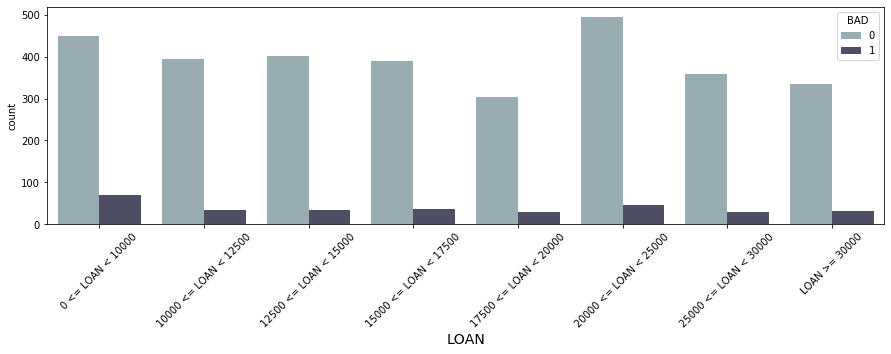

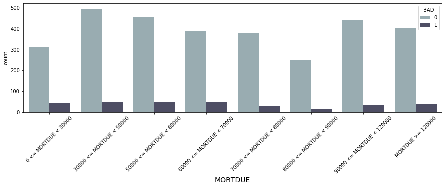

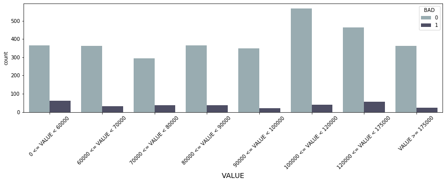

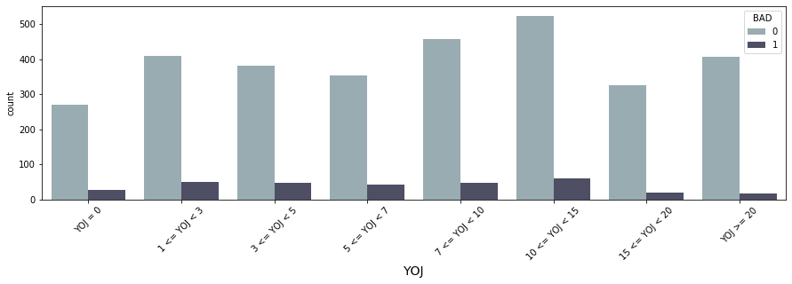

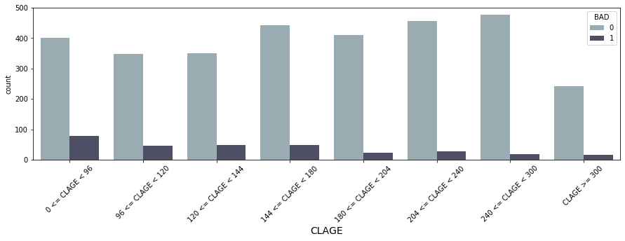

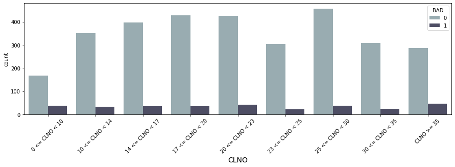

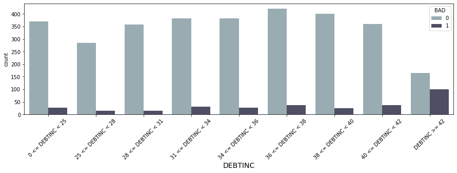

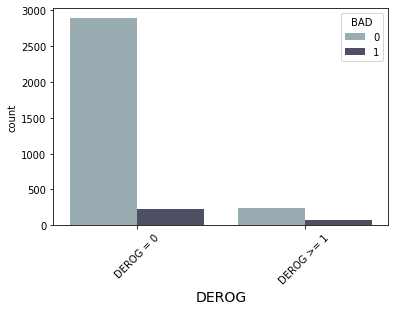

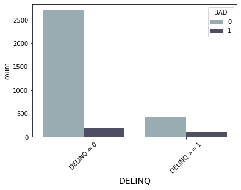

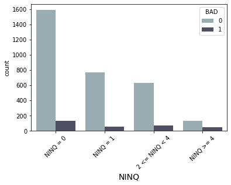

```python
all_cols = cont_cols + disc_cols
data[all_cols] = data[all_cols].astype(float)

intervals = [[0, 10000, 12500, 15000, 17500, 20000, 25000, 30000],    # LOAN
             [0, 30000, 50000, 60000, 70000, 80000, 90000, 120000],   # MORTUDE
             [0, 60000, 70000, 80000, 90000, 100000, 120000, 175000], # VALUE
             [0, 1, 3, 5, 7, 10, 15, 20],                             # YOJ
             [0, 96, 120, 144, 180, 204, 240, 300],                   # CLAGE (equivalent to 8,10,12,15,17,20,25,>25 years)
             [0, 10, 14, 17, 20, 23, 25, 30, 35],                     # CLNO
             [0, 25, 28, 31, 34, 36, 38, 40, 42],                     # DEBTINC
             [0, 1],                                                  # DEROG
             [0, 1],                                                  # DELINQ
             [0, 1, 2, 4]                                             # NINQ
            ]
for i in range(len(all_cols)):
    feature = all_cols[i]
    data = discretise(data, feature, intervals[i])
    order = sort_categories(data[feature].unique())
    if feature in cont_cols:
        plt.figure(figsize=(15,4))
    h = sns.countplot(data=data, x=feature, hue="BAD", order=order, palette="bone_r")
    h.set_xlabel(feature, fontsize=14)
    plt.xticks(rotation=45)
    plt.show()
```

```python
data.to_csv("preprocessed_hmeq.csv", index=False)
```

### Only include 1% bad cases

```python
data = pd.read_csv("preprocessed_hmeq.csv")
```

```python
print('Total           : {} instances'.format(len(data)))
count = data['BAD'].value_counts()[0]
print('Loan repaid     : {} instances ({:.2f}%)'.format(count, count/len(data)*100))
count = data['BAD'].value_counts()[1]
print('Client defaulted:  {} instances ({:.2f}%)\n'.format(count, count/len(data)*100))
```

```
Total           : 3434 instances
Loan repaid     : 3126 instances (91.03%)
Client defaulted:  308 instances (8.97%)
```

Sample **31** instances from BAD = 1 and **3069** from BAD = 0  
Total = 31+3069 = 3100  
Percentage of Client defaulted = 1%  
Percentage of Loan repaid = 99%

```python
count_0 = data['BAD'].value_counts()[0]//99
count_1 = count_0 * 99

one_percent_bad = pd.concat([data[data["BAD"]==1].sample(count_0), data[data["BAD"]==0].sample(count_1)])
one_percent_bad.sample(5)
```

|  | BAD | LOAN | MORTDUE | VALUE | JOB | YOJ | DEROG | DELINQ | CLAGE | NINQ | CLNO | DEBTINC |
| --- | --- | --- | --- | --- | --- | --- | --- | --- | --- | --- | --- | --- |
| 2906 | 0 | 25000 <= LOAN < 30000 | 90000 <= MORTDUE < 120000 | 120000 <= VALUE < 175000 | Mgr | YOJ >= 20 | DEROG = 0 | DELINQ = 0 | 204 <= CLAGE < 240 | NINQ = 0 | 10 <= CLNO < 14 | 38 <= DEBTINC < 40 |
| 774 | 0 | 10000 <= LOAN < 12500 | 50000 <= MORTDUE < 60000 | 80000 <= VALUE < 90000 | Other | 1 <= YOJ < 3 | DEROG = 0 | DELINQ >= 1 | 180 <= CLAGE < 204 | NINQ = 0 | 10 <= CLNO < 14 | 28 <= DEBTINC < 31 |
| 3309 | 0 | LOAN >= 30000 | MORTDUE >= 120000 | VALUE >= 175000 | ProfExe | 3 <= YOJ < 5 | DEROG = 0 | DELINQ = 0 | CLAGE >= 300 | NINQ >= 4 | 14 <= CLNO < 17 | DEBTINC >= 42 |
| 1818 | 0 | 17500 <= LOAN < 20000 | 80000 <= MORTDUE < 90000 | 100000 <= VALUE < 120000 | Other | 15 <= YOJ < 20 | DEROG = 0 | DELINQ = 0 | 144 <= CLAGE < 180 | 2 <= NINQ < 4 | 0 <= CLNO < 10 | 34 <= DEBTINC < 36 |
| 1575 | 0 | 15000 <= LOAN < 17500 | 60000 <= MORTDUE < 70000 | 80000 <= VALUE < 90000 | Other | 1 <= YOJ < 3 | DEROG >= 1 | DELINQ >= 1 | 96 <= CLAGE < 120 | NINQ = 1 | 25 <= CLNO < 30 | 31 <= DEBTINC < 34 |

# Weight of Evidence and Information Value

```python
def calc_woe_iv(df, feature, target, pr=0):
    """
    Calculate the WoE and IV for each feature. Returns
    [0]: the new dataframe with the added weight of evidence feature
    [1]: the information value for that feature
    """
    lst = []

    for val in df[feature].unique():
        lst.append([feature, val, len(df[df[feature] == val]), len(df[(df[feature] == val) & (df[target] == 1)])])

    data = pd.DataFrame(lst, columns=['Variable', 'Value', 'All', 'Bad'])

    data['Share'] = data['All'] / data['All'].sum()
    data['Bad Rate'] = data['Bad'] / data['All']
    data['Distribution Good'] = (data['All'] - data['Bad']) / (data['All'].sum() - data['Bad'].sum())
    data['Distribution Bad'] = data['Bad'] / data['Bad'].sum()
    data['WoE'] = np.log(data['Distribution Good'] / data['Distribution Bad'])
    # Replace infinity WoE to 0.
    data['WoE'].replace({-np.inf: 0, np.inf: 0}, inplace=True)
    data = data.sort_values(by=['Variable', 'Value'], ascending=True)

    # Add the WoE to dataframe
    woe_feature = feature + "_woe"
    df[woe_feature] = df[feature]
    df[woe_feature] = df[woe_feature].map(data.set_index('Value')['WoE'])

    # Information value
    data['IV'] = (data['WoE'] * (data['Distribution Good'] - data['Distribution Bad'])).sum()

    if pr == 1:
        print(data)

    return df, data['IV'].values[0]
```

```python
all_cols = disc_cols + cont_cols + cat_cols
iv_vals = []
for c in all_cols:
    one_percent_bad, iv = calc_woe_iv(one_percent_bad, c, "BAD")
    iv_vals.append((c, iv))

# sort by IV
iv_vals.sort(key = lambda iv_vals: iv_vals[1])
print("Information Value")
for c, iv in iv_vals:
    print("{:8s}: {}".format(c, iv))
```

```
Information Value
YOJ     : 0.07549499544193405
NINQ    : 0.10336783816223782
JOB     : 0.10780641298399746
DEROG   : 0.12609652112058262
VALUE   : 0.13810264592257498
CLNO    : 0.14322383325525131
LOAN    : 0.29159493932195685
CLAGE   : 0.3762991743695827
DELINQ  : 0.4309006505126941
DEBTINC : 0.46139906435354494
MORTDUE : 0.5402266627902815
```

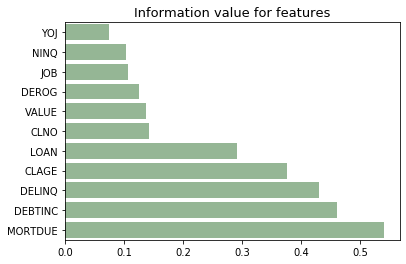

```python
b = sns.barplot(x=[j for i,j in iv_vals], y=[i for i,j in iv_vals], color="darkseagreen")
b.set_title("Information value for features", fontsize=13)
plt.show()
```

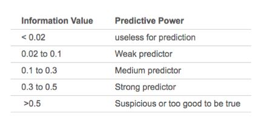

```python
one_percent_bad = one_percent_bad.drop("NINQ", axis=1)
```

**Check if the trends are logical**

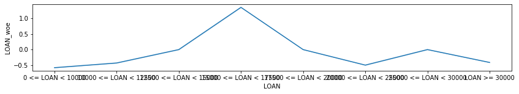

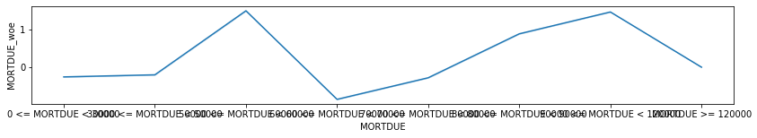

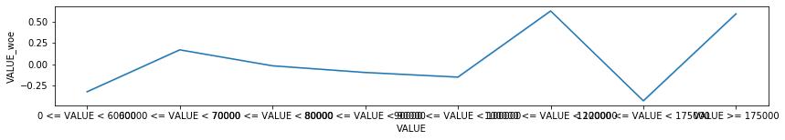

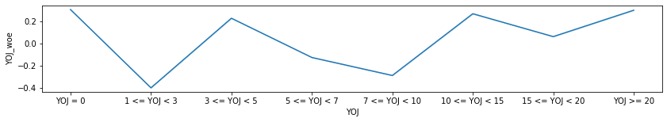

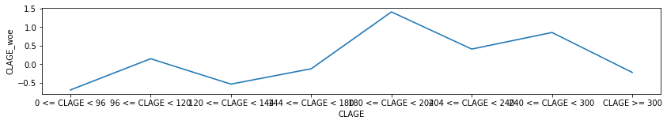

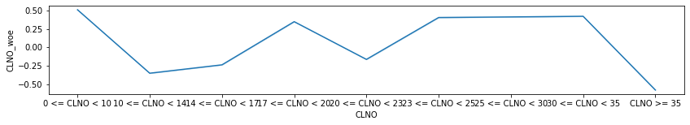

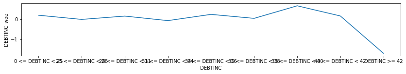

```python
for c in cont_cols:
    plt.figure(figsize=(14,2))
    one_percent_bad[c] = pd.Categorical(one_percent_bad[c], categories=sort_categories(one_percent_bad[c].unique()))
    sns.lineplot(x=c, y=c+"_woe", data=one_percent_bad)
    plt.show()
```

# Feature analysis

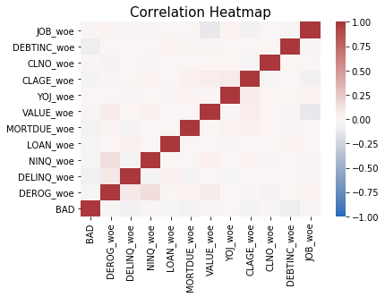

```python
corr = one_percent_bad.drop(["DEROG", "DELINQ"], axis=1).corr()

ax = sns.heatmap(corr,
 vmax=1, vmin=-1, cmap=sns.color_palette("vlag", as_cmap=True));
ax.invert_yaxis()
plt.title("Correlation Heatmap", fontsize=15)

plt.show()
```

# Model Building

```python
one_percent_bad = one_percent_bad.dropna().reset_index(drop=True)
one_percent_bad.head()
```

|  | BAD | LOAN | MORTDUE | VALUE | JOB | YOJ | DEROG | DELINQ | CLAGE | CLNO | ... | DELINQ_woe | NINQ_woe | LOAN_woe | MORTDUE_woe | VALUE_woe | YOJ_woe | CLAGE_woe | CLNO_woe | DEBTINC_woe | JOB_woe |
| --- | --- | --- | --- | --- | --- | --- | --- | --- | --- | --- | --- | --- | --- | --- | --- | --- | --- | --- | --- | --- | --- |
| 0 | 1 | 17500 <= LOAN < 20000 | 70000 <= MORTDUE < 80000 | 90000 <= VALUE < 100000 | Other | 3 <= YOJ < 5 | DEROG >= 1 | DELINQ >= 1 | 0 <= CLAGE < 96 | 30 <= CLNO < 35 | ... | -1.124588 | -1.098612 | 0.000000 | -0.277632 | -0.149532 | 0.227846 | -0.698210 | 0.422160 | -1.692478 | -0.097021 |
| 1 | 1 | 20000 <= LOAN < 25000 | 70000 <= MORTDUE < 80000 | 120000 <= VALUE < 175000 | Office | 15 <= YOJ < 20 | DEROG >= 1 | DELINQ = 0 | 144 <= CLAGE < 180 | 20 <= CLNO < 23 | ... | 0.397201 | -1.098612 | -0.496617 | -0.277632 | -0.427348 | 0.062010 | -0.126916 | -0.164303 | 0.169899 | 0.627036 |
| 2 | 1 | 20000 <= LOAN < 25000 | 60000 <= MORTDUE < 70000 | 90000 <= VALUE < 100000 | ProfExe | 7 <= YOJ < 10 | DEROG >= 1 | DELINQ >= 1 | 144 <= CLAGE < 180 | CLNO >= 35 | ... | -1.124588 | 0.044452 | -0.496617 | -0.852173 | -0.149532 | -0.288805 | -0.126916 | -0.580540 | 0.169899 | -0.185965 |
| 3 | 1 | 10000 <= LOAN < 12500 | 70000 <= MORTDUE < 80000 | 80000 <= VALUE < 90000 | ProfExe | 1 <= YOJ < 3 | DEROG >= 1 | DELINQ = 0 | CLAGE >= 300 | 25 <= CLNO < 30 | ... | 0.397201 | 0.117623 | -0.428455 | -0.277632 | -0.095310 | -0.400427 | -0.225672 | 0.413291 | 0.164201 | -0.185965 |
| 4 | 1 | 10000 <= LOAN < 12500 | 60000 <= MORTDUE < 70000 | 100000 <= VALUE < 120000 | ProfExe | 10 <= YOJ < 15 | DEROG = 0 | DELINQ >= 1 | 120 <= CLAGE < 144 | CLNO >= 35 | ... | -1.124588 | 0.117623 | -0.428455 | -0.852173 | 0.625236 | 0.268561 | -0.540441 | -0.580540 | 0.051672 | -0.185965 |

5 rows × 22 columns

```python
from sklearn.model_selection import train_test_split

x_cols = ["LOAN_woe", "MORTDUE_woe", "VALUE_woe", "YOJ_woe", "CLAGE_woe", "DEBTINC_woe",
          "DEROG_woe", "DELINQ_woe", "CLNO_woe", "JOB_woe"]

X = one_percent_bad[x_cols]
y = one_percent_bad["BAD"]

X_train, X_test, y_train, y_test = train_test_split(X, y, stratify=y, test_size=0.20, random_state=305)
```

### Zero-R classifier (baseline)

Predict the most frequent class. This serves to know how significantly better our other models will do

```python
one_percent_bad["BAD"].value_counts()
```

```
0    3069
1      31
Name: BAD, dtype: int64
```

```python
from sklearn.dummy import DummyClassifier

zero_r = DummyClassifier(strategy='most_frequent')
zero_r.fit(X_train, y_train)
print("Zero-R Accuracy: ", zero_r.score(X_test, y_test))
```

```
Zero-R Accuracy:  0.9903225806451613
```

### Logistic Regression

**Area under Receiver Operating Characterestic (ROC) Curve and Precision-Recall Curve (PRC)**  
Code and information taken from https://machinelearningmastery.com/roc-curves-and-precision-recall-curves-for-classification-in-python/

```python
from sklearn.metrics import roc_curve, roc_auc_score, precision_recall_curve, auc
from sklearn.metrics import confusion_matrix, accuracy_score, precision_score, recall_score, f1_score
def auroc_auprc(fitted_model, X_test, y_test, name):
    sns.set_style("darkgrid")
    # ROC
    rc_probs = [0 for _ in range(len(y_test))]
    model_probs = fitted_model.predict_proba(X_test)[:, 1]
    # calculate scores
    model_auc = roc_auc_score(y_test, model_probs)
    print(name, ': ROC AUC = %.3f' % (model_auc))
    rc_fpr, rc_tpr, _ = roc_curve(y_test, rc_probs)
    model_fpr, model_tpr, _ = roc_curve(y_test, model_probs)

    # PRC
    model_precision, model_recall, _ = precision_recall_curve(y_test, model_probs)
    y_pred = fitted_model.predict(X_test)
    model_auc = auc(model_recall, model_precision)
    print(name, ': PRC AUC = %.3f' % (model_auc))

    fig, (ax1, ax2) = plt.subplots(1, 2, figsize=(12,4))

    # Plot the ROC
    ax1.plot(rc_fpr, rc_tpr, linestyle='--', label='Random')
    ax1.plot(model_fpr, model_tpr, marker='.', label=name)
    ax1.set_xlabel('False Positive Rate')
    ax1.set_ylabel('True Positive Rate')
    ax1.legend()

    # Plot the PRC
    true_pos = len(y_test[y_test==1]) / len(y_test)
    ax2.plot([0, 1], [true_pos, true_pos], linestyle='--', label='Baseline')
    ax2.plot(model_recall, model_precision, marker='.', label=name)
    ax2.set_xlabel('Recall')
    ax2.set_ylabel('Precision')
    ax2.legend()
    plt.show()

def show_results(model, X_test, y_test, name="Model"):
    y_pred = model.predict(X_test)
    print("Accuracy:  ", accuracy_score(y_test,y_pred))
    print("Precision: ", precision_score(y_test,y_pred))
    print("Recall:    ", recall_score(y_test,y_pred))
    print("F1 score:  ", f1_score(y_test,y_pred))

    cm = confusion_matrix(y_test, y_pred)
    cm = pd.DataFrame(cm)
    cm.index.name = 'Actual'
    cm.columns.name = 'Predicted'
    sns.heatmap(cm, annot=True,
        cmap='Blues', cbar=False)
    plt.show()
    auroc_auprc(model, X_test, y_test, name)
```

```python
from sklearn.linear_model import LogisticRegression

lgr = LogisticRegression(solver='liblinear')
lgr.fit(X_train,y_train)
print("Basic logistic Regression Accuracy:", lgr.score(X_test,y_test))
```

```
Basic logistic Regression Accuracy: 0.9903225806451613
```

**Hyperparameters tuning with Grid Search**

```python
from sklearn.model_selection import GridSearchCV

# for liblinear solver
grid={"C":np.logspace(-3,3,7), "penalty":["l1","l2"]}
logreg=LogisticRegression(solver="liblinear")
logreg_cv=GridSearchCV(logreg,grid,cv=10)
logreg_cv.fit(X_train,y_train)

print("Logistic Regression with liblinear solver")
print("tuned hyperparameters :(best parameters) ",logreg_cv.best_params_)
print("accuracy :",logreg_cv.best_score_)
```

```
Logistic Regression with liblinear solver
tuned hyperparameters :(best parameters)  {'C': 100.0, 'penalty': 'l1'}
accuracy : 0.9907258064516129
```

```python
from sklearn.model_selection import GridSearchCV

# for lbfgs
grid={"C":np.logspace(-3,3,7)}
logreg=LogisticRegression(solver="lbfgs")
logreg_cv=GridSearchCV(logreg,grid,cv=10)
logreg_cv.fit(X_train,y_train)

print("Logistic Regression with lbfgs solver")
print("tuned hyperparameters :(best parameters) ",logreg_cv.best_params_)
print("accuracy :",logreg_cv.best_score_)
```

```
Logistic Regression with lbfgs solver
tuned hyperparameters :(best parameters)  {'C': 100.0}
accuracy : 0.9907258064516129
```

```
Accuracy:   0.9903225806451613
Precision:  0.0
Recall:     0.0
F1 score:   0.0
```

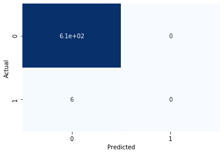

```
Logistic : ROC AUC = 0.810
Logistic : PRC AUC = 0.058
```

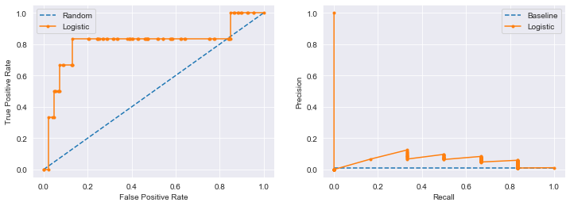

```python
lgr = LogisticRegression(solver="liblinear", C=0.01, penalty="l2")
lgr.fit(X_train, y_train)
show_results(lgr, X_test, y_test, "Logistic")
```

## Support Vector Machines

```python
from sklearn import svm

# For linear and sigmoid kernels
grid={"C":np.logspace(-2,2,5)}

linsvc = svm.SVC(kernel="linear")
linsvc_cv=GridSearchCV(linsvc,grid,cv=10)
linsvc_cv.fit(X_train,y_train)

print("Gridsearch for SVC with linear kernel")
print("tuned hyperparameters :(best parameters) ",linsvc_cv.best_params_)
print("accuracy :",linsvc_cv.best_score_)
```

```
Gridsearch for SVC with linear kernel
tuned hyperparameters :(best parameters)  {'C': 0.01}
accuracy : 0.9899193548387096
```

```
Accuracy:   0.9903225806451613
Precision:  0.0
Recall:     0.0
F1 score:   0.0
```

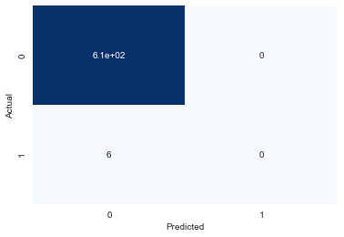

```
SVM : ROC AUC = 0.727
SVM : PRC AUC = 0.064
```

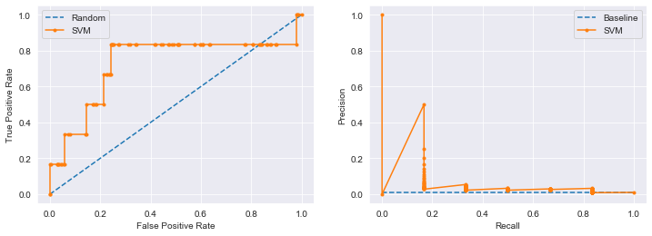

```python
svc = svm.SVC(kernel="linear", C=0.01, probability=True)
svc.fit(X_train, y_train)
show_results(svc, X_test, y_test, "SVM")
```

### Conclusion

In both cases, the accuracy and AUROC and AUPRC are worse than in part 1 of the project. It also has 0 precision and recall - not predicting BAD=1 at all. This is because of the highly imbalanced dataset. This is the motive for applying a SMOTE algorithm.

# Apply SMOTE algorithm

```python
data = pd.read_csv("hmeq.csv")
data = data.drop('REASON', axis=1)
data = data.dropna()

X=data.drop('BAD',axis=1)
y=data['BAD']
```

```python
from imblearn.over_sampling import SMOTENC
smote_nc = SMOTENC(categorical_features=[3], random_state=0)
X_resampled, y_resampled = smote_nc.fit_resample(X, y)

data = pd.DataFrame(X_resampled, columns=X.columns)
data["BAD"] = y_resampled
data.head()
```

|  | LOAN | MORTDUE | VALUE | JOB | YOJ | DEROG | DELINQ | CLAGE | NINQ | CLNO | DEBTINC | BAD |
| --- | --- | --- | --- | --- | --- | --- | --- | --- | --- | --- | --- | --- |
| 0 | 1700 | 30548 | 40320 | Other | 9 | 0 | 0 | 101.466 | 1 | 8 | 37.1136 | 1 |
| 1 | 1800 | 28502 | 43034 | Other | 11 | 0 | 0 | 88.766 | 0 | 8 | 36.8849 | 1 |
| 2 | 2300 | 102370 | 120953 | Office | 2 | 0 | 0 | 90.9925 | 0 | 13 | 31.5885 | 0 |
| 3 | 2400 | 34863 | 47471 | Mgr | 12 | 0 | 0 | 70.4911 | 1 | 21 | 38.2636 | 1 |
| 4 | 2400 | 98449 | 117195 | Office | 4 | 0 | 0 | 93.8118 | 0 | 13 | 29.6818 | 0 |

```python
print('Total           : {} instances'.format(len(data)))
count = data['BAD'].value_counts()[0]
print('Loan repaid     : {} instances ({:.2f}%)'.format(count, count/len(data)*100))
count = data['BAD'].value_counts()[1]
print('Client defaulted:  {} instances ({:.2f}%)'.format(count, count/len(data)*100))
```

```
Total           : 6252 instances
Loan repaid     : 3126 instances (50.00%)
Client defaulted:  3126 instances (50.00%)
```

```python
cont_cols = ["LOAN", "MORTDUE", "VALUE", "YOJ", "CLAGE", "CLNO", "DEBTINC"] # Continuous variables
disc_cols = ["DEROG", "DELINQ", "NINQ"] # Discrete variables
cat_cols = ["JOB"] # Categorical variables
```

```python
data[cont_cols] = data[cont_cols].astype(float)
```

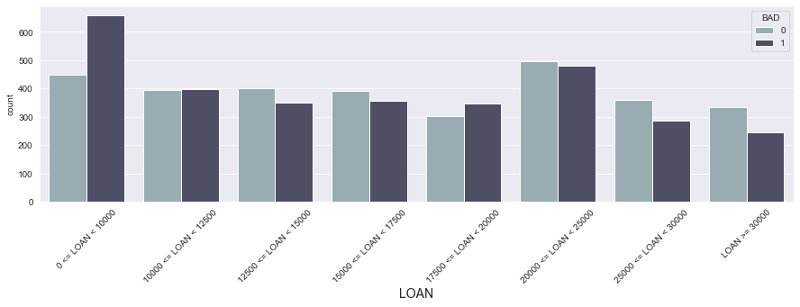

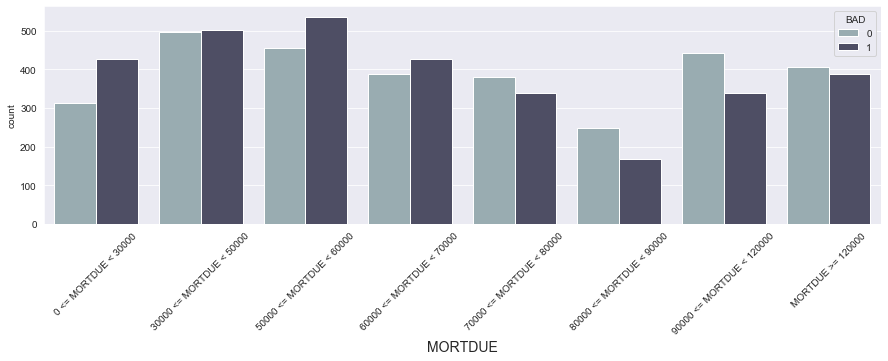

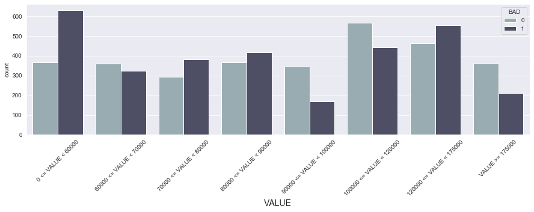

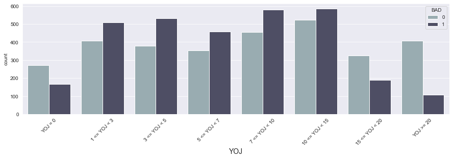

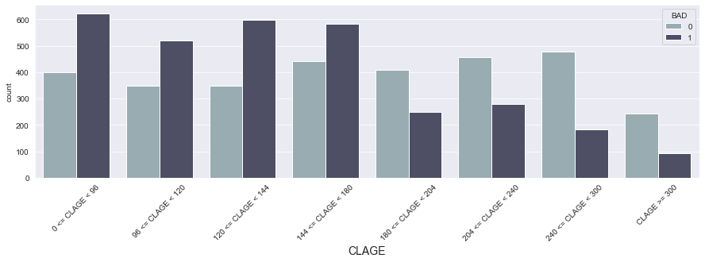

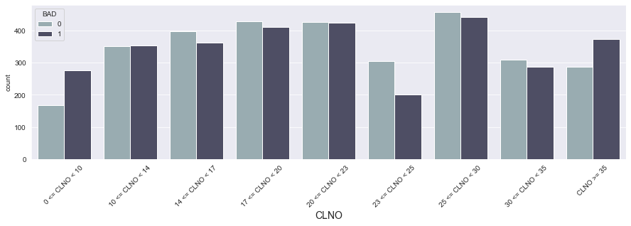

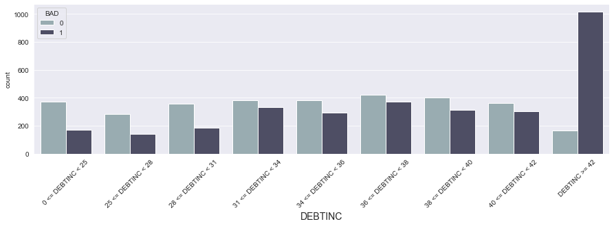

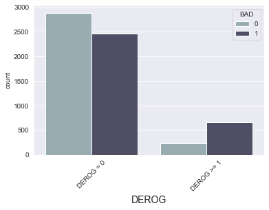

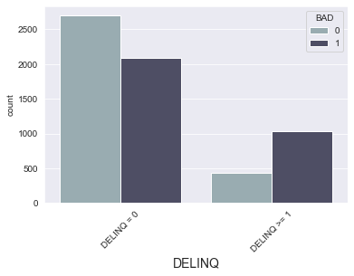

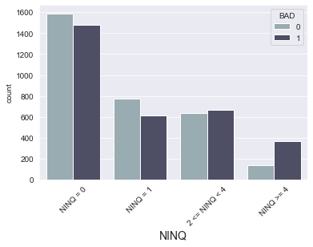

```python
all_cols = cont_cols + disc_cols
data[all_cols] = data[all_cols].astype(float)

intervals = [[0, 10000, 12500, 15000, 17500, 20000, 25000, 30000],    # LOAN
             [0, 30000, 50000, 60000, 70000, 80000, 90000, 120000],   # MORTUDE
             [0, 60000, 70000, 80000, 90000, 100000, 120000, 175000], # VALUE
             [0, 1, 3, 5, 7, 10, 15, 20],                             # YOJ
             [0, 96, 120, 144, 180, 204, 240, 300],                   # CLAGE (equivalent to 8,10,12,15,17,20,25,>25 years)
             [0, 10, 14, 17, 20, 23, 25, 30, 35],                     # CLNO
             [0, 25, 28, 31, 34, 36, 38, 40, 42],                     # DEBTINC
             [0, 1],                                                  # DEROG
             [0, 1],                                                  # DELINQ
             [0, 1, 2, 4]                                             # NINQ
            ]
for i in range(len(all_cols)):
    feature = all_cols[i]
    data = discretise(data, feature, intervals[i])
    order = sort_categories(data[feature].unique())
    if feature in cont_cols:
        plt.figure(figsize=(15,4))
    h = sns.countplot(data=data, x=feature, hue="BAD", order=order, palette="bone_r")
    h.set_xlabel(feature, fontsize=14)
    plt.xticks(rotation=45)
    plt.show()
```

```
Information Value
MORTDUE : 0.03802216065996669
CLNO    : 0.03995662869155252
LOAN    : 0.044564734382703114
NINQ    : 0.09010180952964539
JOB     : 0.11536802088993875
VALUE   : 0.13940656688935493
DEROG   : 0.16128923896713
YOJ     : 0.21068188977597585
DELINQ  : 0.21750072349174848
CLAGE   : 0.30025591758986586
DEBTINC : 0.6332574208290489
```

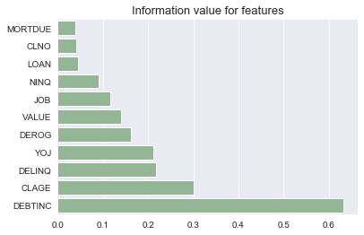

```python
all_cols = disc_cols + cont_cols + cat_cols
iv_vals = []
for c in all_cols:
    data, iv = calc_woe_iv(data, c, "BAD")
    iv_vals.append((c, iv))

# sort by IV
iv_vals.sort(key = lambda iv_vals: iv_vals[1])
print("Information Value")
for c, iv in iv_vals:
    print("{:8s}: {}".format(c, iv))

b = sns.barplot(x=[j for i,j in iv_vals], y=[i for i,j in iv_vals], color="darkseagreen")
b.set_title("Information value for features", fontsize=13)
plt.show()
```

### Build model

```python
data = data.dropna().reset_index(drop=True)
print(len(data))
data.head()
```

```
6252
```

|  | LOAN | MORTDUE | VALUE | JOB | YOJ | DEROG | DELINQ | CLAGE | NINQ | CLNO | ... | DELINQ_woe | NINQ_woe | LOAN_woe | MORTDUE_woe | VALUE_woe | YOJ_woe | CLAGE_woe | CLNO_woe | DEBTINC_woe | JOB_woe |
| --- | --- | --- | --- | --- | --- | --- | --- | --- | --- | --- | --- | --- | --- | --- | --- | --- | --- | --- | --- | --- | --- |
| 0 | 0 <= LOAN < 10000 | 30000 <= MORTDUE < 50000 | 0 <= VALUE < 60000 | Other | 7 <= YOJ < 10 | DEROG = 0 | DELINQ = 0 | 96 <= CLAGE < 120 | NINQ = 1 | 0 <= CLNO < 10 | ... | 0.252586 | 0.232252 | -0.383701 | -0.008016 | -0.541498 | -0.238810 | -0.401626 | -0.492807 | 0.129130 | -0.336351 |
| 1 | 0 <= LOAN < 10000 | 0 <= MORTDUE < 30000 | 0 <= VALUE < 60000 | Other | 10 <= YOJ < 15 | DEROG = 0 | DELINQ = 0 | 0 <= CLAGE < 96 | NINQ = 0 | 0 <= CLNO < 10 | ... | 0.252586 | 0.071109 | -0.383701 | -0.316120 | -0.541498 | -0.110120 | -0.443082 | -0.492807 | 0.129130 | -0.336351 |
| 2 | 0 <= LOAN < 10000 | 90000 <= MORTDUE < 120000 | 120000 <= VALUE < 175000 | Office | 1 <= YOJ < 3 | DEROG = 0 | DELINQ = 0 | 0 <= CLAGE < 96 | NINQ = 0 | 10 <= CLNO < 14 | ... | 0.252586 | 0.071109 | -0.383701 | 0.270524 | -0.181241 | -0.221181 | -0.443082 | -0.011364 | 0.134280 | 0.297798 |
| 3 | 0 <= LOAN < 10000 | 30000 <= MORTDUE < 50000 | 0 <= VALUE < 60000 | Mgr | 10 <= YOJ < 15 | DEROG = 0 | DELINQ = 0 | 0 <= CLAGE < 96 | NINQ = 1 | 20 <= CLNO < 23 | ... | 0.252586 | 0.232252 | -0.383701 | -0.008016 | -0.541498 | -0.110120 | -0.443082 | 0.007067 | 0.250958 | 0.029779 |
| 4 | 0 <= LOAN < 10000 | 90000 <= MORTDUE < 120000 | 100000 <= VALUE < 120000 | Office | 3 <= YOJ < 5 | DEROG = 0 | DELINQ = 0 | 0 <= CLAGE < 96 | NINQ = 0 | 10 <= CLNO < 14 | ... | 0.252586 | 0.071109 | -0.383701 | 0.270524 | 0.247284 | -0.332706 | -0.443082 | -0.011364 | 0.671047 | 0.297798 |

5 rows × 23 columns

```python
from sklearn.model_selection import train_test_split

x_cols = ["VALUE_woe", "YOJ_woe", "CLAGE_woe", "DEBTINC_woe",
          "DEROG_woe", "DELINQ_woe", "JOB_woe"]

X = data[x_cols]
y = data["BAD"]

X_train, X_test, y_train, y_test = train_test_split(X, y, stratify=y, test_size=0.20, random_state=305)
```

### Zero-R Classifier

```python
from sklearn.dummy import DummyClassifier

zero_r = DummyClassifier(strategy='most_frequent')
zero_r.fit(X_train, y_train)
print("Zero-R Accuracy: ", zero_r.score(X_test, y_test))
```

```
Zero-R Accuracy:  0.49960031974420466
```

### Logistic Regression

```python
from sklearn.linear_model import LogisticRegression

lgr = LogisticRegression(solver='liblinear')
lgr.fit(X_train,y_train)
print("Basic logistic Regression Accuracy:", lgr.score(X_test,y_test))
```

```
Basic logistic Regression Accuracy: 0.7641886490807354
```

```python
from sklearn.model_selection import GridSearchCV

# for liblinear solver
grid={"C":np.logspace(-3,3,7), "penalty":["l1","l2"]}
logreg=LogisticRegression(solver="liblinear")
logreg_cv=GridSearchCV(logreg,grid,cv=10)
logreg_cv.fit(X_train,y_train)

print("Logistic Regression with liblinear solver")
print("tuned hyperparameters :(best parameters) ",logreg_cv.best_params_)
print("accuracy :",logreg_cv.best_score_)
```

```
Logistic Regression with liblinear solver
tuned hyperparameters :(best parameters)  {'C': 0.1, 'penalty': 'l1'}
accuracy : 0.7530493901219756
```

```python
from sklearn.model_selection import GridSearchCV

# for lbfgs
grid={"C":np.logspace(-3,3,7)}
logreg=LogisticRegression(solver="lbfgs")
logreg_cv=GridSearchCV(logreg,grid,cv=10)
logreg_cv.fit(X_train,y_train)

print("Logistic Regression with lbfgs solver")
print("tuned hyperparameters :(best parameters) ",logreg_cv.best_params_)
print("accuracy :",logreg_cv.best_score_)
```

```
Logistic Regression with lbfgs solver
tuned hyperparameters :(best parameters)  {'C': 0.1}
accuracy : 0.7520495900819836
```

```
Accuracy:   0.762589928057554
Precision:  0.7701149425287356
Recall:     0.7492012779552716
F1 score:   0.7595141700404858
```

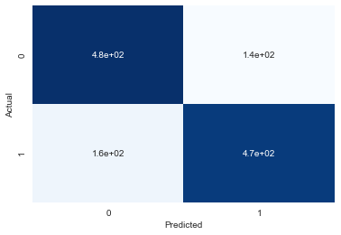

```
Logistic : ROC AUC = 0.835
Logistic : PRC AUC = 0.831
```

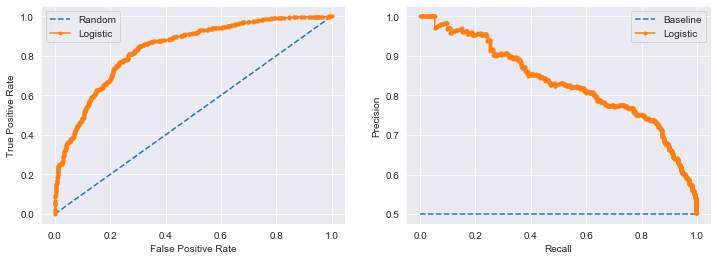

```python
from sklearn.metrics import confusion_matrix, accuracy_score, precision_score, recall_score, f1_score

lgr = LogisticRegression(solver="liblinear", C=0.1, penalty="l1")
lgr.fit(X_train, y_train)
show_results(lgr, X_test, y_test, "Logistic")
```

### Support Vector Machines

```python
from sklearn import svm

# For linear and sigmoid kernels
grid={"C":np.logspace(-2,2,5)}

linsvc = svm.SVC(kernel="linear")
linsvc_cv=GridSearchCV(linsvc,grid,cv=10)
linsvc_cv.fit(X_train,y_train)

print("Gridsearch for SVC with linear kernel")
print("tuned hyperparameters :(best parameters) ",linsvc_cv.best_params_)
print("accuracy :",linsvc_cv.best_score_)
```

```
Gridsearch for SVC with linear kernel
tuned hyperparameters :(best parameters)  {'C': 0.1}
accuracy : 0.7528494301139772
```

```
Accuracy:   0.7673860911270983
Precision:  0.7654516640253566
Recall:     0.7715654952076677
F1 score:   0.7684964200477328
```

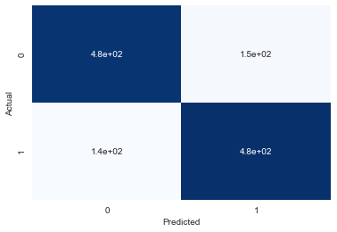

```
SVM : ROC AUC = 0.835
SVM : PRC AUC = 0.831
```

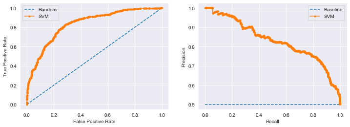

```python
svc = svm.SVC(kernel="linear", C=0.1, probability=True)
svc.fit(X_train, y_train)
show_results(svc, X_test, y_test, "SVM")
```

### Conclusion

Using the SMOTE algorithm, we have a much stronger AUPRC